# Overview

Dataset info

| Number of variables | 15 |
| --- | --- |
| Number of observations | 891 |
| Total Missing (%) | 6.5% |
| Total size in memory | 80.6 KiB |
| Average record size in memory | 92.6 B |

Variables types

| Numeric | 5 |
| --- | --- |
| Categorical | 7 |
| Boolean | 3 |
| Date | 0 |
| Text (Unique) | 0 |
| Rejected | 0 |
| Unsupported | 0 |

Warnings

- `age` has 177 / 19.9% missing values Missing
- `deck` has 688 / 77.2% missing values Missing
- `fare` has 15 / 1.7% zeros Zeros
- `parch` has 678 / 76.1% zeros Zeros
- `sibsp` has 608 / 68.2% zeros Zeros
- Dataset has 107 duplicate rows Warning

# Variables

adult_male  
Boolean

| Distinct count | 2 |
| --- | --- |
| Unique (%) | 0.2% |
| Missing (%) | 0.0% |
| Missing (n) | 0 |

| Mean | 0.60269 |
| --- | --- |

| True | 537 |
| --- | --- |
| (Missing) | 354 |

Toggle details

| Value | Count | Frequency (%) |  |
| --- | --- | --- | --- |
| True | 537 | 60.3% |  |
| (Missing) | 354 | 39.7% |  |

age  
Numeric

| Distinct count | 89 |
| --- | --- |
| Unique (%) | 10.0% |
| Missing (%) | 19.9% |
| Missing (n) | 177 |
| Infinite (%) | 0.0% |
| Infinite (n) | 0 |

| Mean | 29.699 |
| --- | --- |
| Minimum | 0.42 |
| Maximum | 80 |
| Zeros (%) | 0.0% |

Toggle details

**Statistics**

Quantile statistics

| Minimum | 0.42 |
| --- | --- |
| 5-th percentile | 4 |
| Q1 | 20.125 |
| Median | 28 |
| Q3 | 38 |
| 95-th percentile | 56 |
| Maximum | 80 |
| Range | 79.58 |
| Interquartile range | 17.875 |

Descriptive statistics

| Standard deviation | 14.526 |
| --- | --- |
| Coef of variation | 0.48912 |
| Kurtosis | 0.17827 |
| Mean | 29.699 |
| MAD | 11.323 |
| Skewness | 0.38911 |
| Sum | 21205 |
| Variance | 211.02 |
| Memory size | 7.0 KiB |

**Histogram**

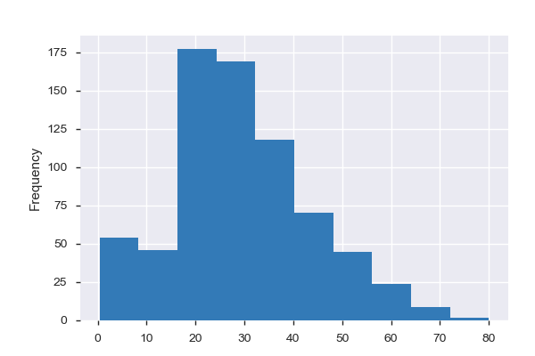

**Common Values**

| Value | Count | Frequency (%) |  |
| --- | --- | --- | --- |
| 24.0 | 30 | 3.4% |  |
| 22.0 | 27 | 3.0% |  |
| 18.0 | 26 | 2.9% |  |
| 28.0 | 25 | 2.8% |  |
| 19.0 | 25 | 2.8% |  |
| 30.0 | 25 | 2.8% |  |
| 21.0 | 24 | 2.7% |  |
| 25.0 | 23 | 2.6% |  |
| 36.0 | 22 | 2.5% |  |
| 29.0 | 20 | 2.2% |  |
| Other values (78) | 467 | 52.4% |  |
| (Missing) | 177 | 19.9% |  |

**Extreme Values**

Minimum 5 values

| Value | Count | Frequency (%) |  |
| --- | --- | --- | --- |
| 0.42 | 1 | 0.1% |  |
| 0.67 | 1 | 0.1% |  |
| 0.75 | 2 | 0.2% |  |
| 0.83 | 2 | 0.2% |  |
| 0.92 | 1 | 0.1% |  |

Maximum 5 values

| Value | Count | Frequency (%) |  |
| --- | --- | --- | --- |
| 70.0 | 2 | 0.2% |  |
| 70.5 | 1 | 0.1% |  |
| 71.0 | 2 | 0.2% |  |
| 74.0 | 1 | 0.1% |  |
| 80.0 | 1 | 0.1% |  |

alive  
Categorical

| Distinct count | 2 |
| --- | --- |
| Unique (%) | 0.2% |
| Missing (%) | 0.0% |
| Missing (n) | 0 |

| no | 549 |
| --- | --- |
| yes | 342 |

Toggle details

| Value | Count | Frequency (%) |  |
| --- | --- | --- | --- |
| no | 549 | 61.6% |  |
| yes | 342 | 38.4% |  |

alone  
Boolean

| Distinct count | 2 |
| --- | --- |
| Unique (%) | 0.2% |
| Missing (%) | 0.0% |
| Missing (n) | 0 |

| Mean | 0.60269 |
| --- | --- |

| True | 537 |
| --- | --- |
| (Missing) | 354 |

Toggle details

| Value | Count | Frequency (%) |  |
| --- | --- | --- | --- |
| True | 537 | 60.3% |  |
| (Missing) | 354 | 39.7% |  |

class  
Categorical

| Distinct count | 3 |
| --- | --- |
| Unique (%) | 0.3% |
| Missing (%) | 0.0% |
| Missing (n) | 0 |

| Third | 491 |
| --- | --- |
| First | 216 |
| Second | 184 |

Toggle details

| Value | Count | Frequency (%) |  |
| --- | --- | --- | --- |
| Third | 491 | 55.1% |  |
| First | 216 | 24.2% |  |
| Second | 184 | 20.7% |  |

deck  
Categorical

| Distinct count | 8 |
| --- | --- |
| Unique (%) | 0.9% |
| Missing (%) | 77.2% |
| Missing (n) | 688 |

| C | 59 |
| --- | --- |
| B | 47 |
| D | 33 |
| Other values (4) | 64 |
| (Missing) | 688 |

Toggle details

| Value | Count | Frequency (%) |  |
| --- | --- | --- | --- |
| C | 59 | 6.6% |  |
| B | 47 | 5.3% |  |
| D | 33 | 3.7% |  |
| E | 32 | 3.6% |  |
| A | 15 | 1.7% |  |
| F | 13 | 1.5% |  |
| G | 4 | 0.4% |  |
| (Missing) | 688 | 77.2% |  |

embark_town  
Categorical

| Distinct count | 4 |
| --- | --- |
| Unique (%) | 0.4% |
| Missing (%) | 0.2% |
| Missing (n) | 2 |

| Southampton | 644 |
| --- | --- |
| Cherbourg | 168 |
| Queenstown | 77 |
| (Missing) | 2 |

Toggle details

| Value | Count | Frequency (%) |  |
| --- | --- | --- | --- |
| Southampton | 644 | 72.3% |  |
| Cherbourg | 168 | 18.9% |  |
| Queenstown | 77 | 8.6% |  |
| (Missing) | 2 | 0.2% |  |

embarked  
Categorical

| Distinct count | 4 |
| --- | --- |
| Unique (%) | 0.4% |
| Missing (%) | 0.2% |
| Missing (n) | 2 |

| S | 644 |
| --- | --- |
| C | 168 |
| Q | 77 |
| (Missing) | 2 |

Toggle details

| Value | Count | Frequency (%) |  |
| --- | --- | --- | --- |
| S | 644 | 72.3% |  |
| C | 168 | 18.9% |  |
| Q | 77 | 8.6% |  |
| (Missing) | 2 | 0.2% |  |

fare  
Numeric

| Distinct count | 248 |
| --- | --- |
| Unique (%) | 27.8% |
| Missing (%) | 0.0% |
| Missing (n) | 0 |
| Infinite (%) | 0.0% |
| Infinite (n) | 0 |

| Mean | 32.204 |
| --- | --- |
| Minimum | 0 |
| Maximum | 512.33 |
| Zeros (%) | 1.7% |

Toggle details

**Statistics**

Quantile statistics

| Minimum | 0 |
| --- | --- |
| 5-th percentile | 7.225 |
| Q1 | 7.9104 |
| Median | 14.454 |
| Q3 | 31 |
| 95-th percentile | 112.08 |
| Maximum | 512.33 |
| Range | 512.33 |
| Interquartile range | 23.09 |

Descriptive statistics

| Standard deviation | 49.693 |
| --- | --- |
| Coef of variation | 1.5431 |
| Kurtosis | 33.398 |
| Mean | 32.204 |
| MAD | 28.164 |
| Skewness | 4.7873 |
| Sum | 28694 |
| Variance | 2469.4 |
| Memory size | 7.0 KiB |

**Histogram**

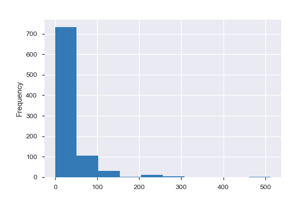

**Common Values**

| Value | Count | Frequency (%) |  |
| --- | --- | --- | --- |
| 8.05 | 43 | 4.8% |  |
| 13.0 | 42 | 4.7% |  |
| 7.8958 | 38 | 4.3% |  |
| 7.75 | 34 | 3.8% |  |
| 26.0 | 31 | 3.5% |  |
| 10.5 | 24 | 2.7% |  |
| 7.925 | 18 | 2.0% |  |
| 7.775 | 16 | 1.8% |  |
| 26.55 | 15 | 1.7% |  |
| 0.0 | 15 | 1.7% |  |
| Other values (238) | 615 | 69.0% |  |

**Extreme Values**

Minimum 5 values

| Value | Count | Frequency (%) |  |
| --- | --- | --- | --- |
| 0.0 | 15 | 1.7% |  |
| 4.0125 | 1 | 0.1% |  |
| 5.0 | 1 | 0.1% |  |
| 6.2375 | 1 | 0.1% |  |
| 6.4375 | 1 | 0.1% |  |

Maximum 5 values

| Value | Count | Frequency (%) |  |
| --- | --- | --- | --- |
| 227.525 | 4 | 0.4% |  |
| 247.5208 | 2 | 0.2% |  |
| 262.375 | 2 | 0.2% |  |
| 263.0 | 4 | 0.4% |  |
| 512.3292 | 3 | 0.3% |  |

parch  
Numeric

| Distinct count | 7 |
| --- | --- |
| Unique (%) | 0.8% |
| Missing (%) | 0.0% |
| Missing (n) | 0 |
| Infinite (%) | 0.0% |
| Infinite (n) | 0 |

| Mean | 0.38159 |
| --- | --- |
| Minimum | 0 |
| Maximum | 6 |
| Zeros (%) | 76.1% |

Toggle details

**Statistics**

Quantile statistics

| Minimum | 0 |
| --- | --- |
| 5-th percentile | 0 |
| Q1 | 0 |
| Median | 0 |
| Q3 | 0 |
| 95-th percentile | 2 |
| Maximum | 6 |
| Range | 6 |
| Interquartile range | 0 |

Descriptive statistics

| Standard deviation | 0.80606 |
| --- | --- |
| Coef of variation | 2.1123 |
| Kurtosis | 9.7781 |
| Mean | 0.38159 |
| MAD | 0.58074 |
| Skewness | 2.7491 |
| Sum | 340 |
| Variance | 0.64973 |
| Memory size | 7.0 KiB |

**Histogram**

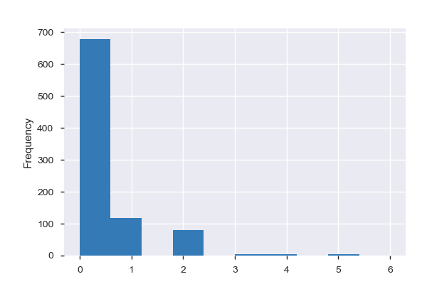

**Common Values**

| Value | Count | Frequency (%) |  |
| --- | --- | --- | --- |
| 0 | 678 | 76.1% |  |
| 1 | 118 | 13.2% |  |
| 2 | 80 | 9.0% |  |
| 5 | 5 | 0.6% |  |
| 3 | 5 | 0.6% |  |
| 4 | 4 | 0.4% |  |
| 6 | 1 | 0.1% |  |

**Extreme Values**

Minimum 5 values

| Value | Count | Frequency (%) |  |
| --- | --- | --- | --- |
| 0 | 678 | 76.1% |  |
| 1 | 118 | 13.2% |  |
| 2 | 80 | 9.0% |  |
| 3 | 5 | 0.6% |  |
| 4 | 4 | 0.4% |  |

Maximum 5 values

| Value | Count | Frequency (%) |  |
| --- | --- | --- | --- |
| 2 | 80 | 9.0% |  |
| 3 | 5 | 0.6% |  |
| 4 | 4 | 0.4% |  |
| 5 | 5 | 0.6% |  |
| 6 | 1 | 0.1% |  |

pclass  
Numeric

| Distinct count | 3 |
| --- | --- |
| Unique (%) | 0.3% |
| Missing (%) | 0.0% |
| Missing (n) | 0 |
| Infinite (%) | 0.0% |
| Infinite (n) | 0 |

| Mean | 2.3086 |
| --- | --- |
| Minimum | 1 |
| Maximum | 3 |
| Zeros (%) | 0.0% |

Toggle details

**Statistics**

Quantile statistics

| Minimum | 1 |
| --- | --- |
| 5-th percentile | 1 |
| Q1 | 2 |
| Median | 3 |
| Q3 | 3 |
| 95-th percentile | 3 |
| Maximum | 3 |
| Range | 2 |
| Interquartile range | 1 |

Descriptive statistics

| Standard deviation | 0.83607 |
| --- | --- |
| Coef of variation | 0.36215 |
| Kurtosis | -1.28 |
| Mean | 2.3086 |
| MAD | 0.76197 |
| Skewness | -0.63055 |
| Sum | 2057 |
| Variance | 0.69902 |
| Memory size | 7.0 KiB |

**Histogram**

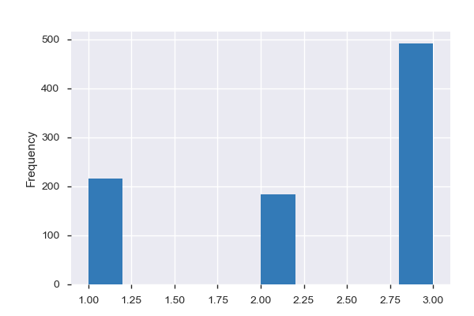

**Common Values**

| Value | Count | Frequency (%) |  |
| --- | --- | --- | --- |
| 3 | 491 | 55.1% |  |
| 1 | 216 | 24.2% |  |
| 2 | 184 | 20.7% |  |

**Extreme Values**

Minimum 5 values

| Value | Count | Frequency (%) |  |
| --- | --- | --- | --- |
| 1 | 216 | 24.2% |  |
| 2 | 184 | 20.7% |  |
| 3 | 491 | 55.1% |  |

Maximum 5 values

| Value | Count | Frequency (%) |  |
| --- | --- | --- | --- |
| 1 | 216 | 24.2% |  |
| 2 | 184 | 20.7% |  |
| 3 | 491 | 55.1% |  |

sex  
Categorical

| Distinct count | 2 |
| --- | --- |
| Unique (%) | 0.2% |
| Missing (%) | 0.0% |
| Missing (n) | 0 |

| male | 577 |
| --- | --- |
| female | 314 |

Toggle details

| Value | Count | Frequency (%) |  |
| --- | --- | --- | --- |
| male | 577 | 64.8% |  |
| female | 314 | 35.2% |  |

sibsp  
Numeric

| Distinct count | 7 |
| --- | --- |
| Unique (%) | 0.8% |
| Missing (%) | 0.0% |
| Missing (n) | 0 |
| Infinite (%) | 0.0% |
| Infinite (n) | 0 |

| Mean | 0.52301 |
| --- | --- |
| Minimum | 0 |
| Maximum | 8 |
| Zeros (%) | 68.2% |

Toggle details

**Statistics**

Quantile statistics

| Minimum | 0 |
| --- | --- |
| 5-th percentile | 0 |
| Q1 | 0 |
| Median | 0 |
| Q3 | 1 |
| 95-th percentile | 3 |
| Maximum | 8 |
| Range | 8 |
| Interquartile range | 1 |

Descriptive statistics

| Standard deviation | 1.1027 |
| --- | --- |
| Coef of variation | 2.1085 |
| Kurtosis | 17.88 |
| Mean | 0.52301 |
| MAD | 0.71378 |
| Skewness | 3.6954 |
| Sum | 466 |
| Variance | 1.216 |
| Memory size | 7.0 KiB |

**Histogram**

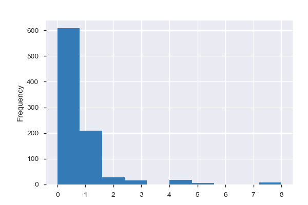

**Common Values**

| Value | Count | Frequency (%) |  |
| --- | --- | --- | --- |
| 0 | 608 | 68.2% |  |
| 1 | 209 | 23.5% |  |
| 2 | 28 | 3.1% |  |
| 4 | 18 | 2.0% |  |
| 3 | 16 | 1.8% |  |
| 8 | 7 | 0.8% |  |
| 5 | 5 | 0.6% |  |

**Extreme Values**

Minimum 5 values

| Value | Count | Frequency (%) |  |
| --- | --- | --- | --- |
| 0 | 608 | 68.2% |  |
| 1 | 209 | 23.5% |  |
| 2 | 28 | 3.1% |  |
| 3 | 16 | 1.8% |  |
| 4 | 18 | 2.0% |  |

Maximum 5 values

| Value | Count | Frequency (%) |  |
| --- | --- | --- | --- |
| 2 | 28 | 3.1% |  |
| 3 | 16 | 1.8% |  |
| 4 | 18 | 2.0% |  |
| 5 | 5 | 0.6% |  |
| 8 | 7 | 0.8% |  |

survived  
Boolean

| Distinct count | 2 |
| --- | --- |
| Unique (%) | 0.2% |
| Missing (%) | 0.0% |
| Missing (n) | 0 |

| Mean | 0.38384 |
| --- | --- |

| 0 | 549 |
| --- | --- |
| 1 | 342 |

Toggle details

| Value | Count | Frequency (%) |  |
| --- | --- | --- | --- |
| 0 | 549 | 61.6% |  |
| 1 | 342 | 38.4% |  |

who  
Categorical

| Distinct count | 3 |
| --- | --- |
| Unique (%) | 0.3% |
| Missing (%) | 0.0% |
| Missing (n) | 0 |

| man | 537 |
| --- | --- |
| woman | 271 |
| child | 83 |

Toggle details

| Value | Count | Frequency (%) |  |
| --- | --- | --- | --- |
| man | 537 | 60.3% |  |
| woman | 271 | 30.4% |  |
| child | 83 | 9.3% |  |

# Correlations

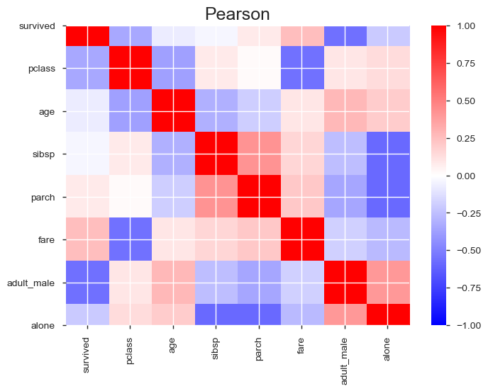

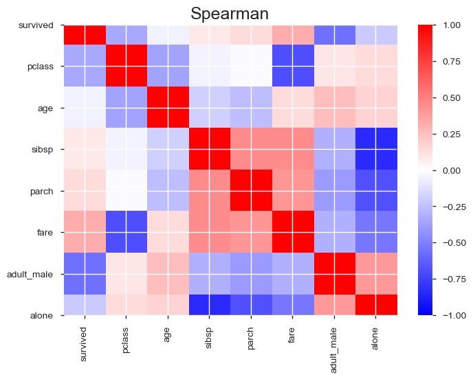

# Sample

|  | survived | pclass | sex | age | sibsp | parch | fare | embarked | class | who | adult_male | deck | embark_town | alive | alone |
| --- | --- | --- | --- | --- | --- | --- | --- | --- | --- | --- | --- | --- | --- | --- | --- |
| 0 | 0 | 3 | male | 22.0 | 1 | 0 | 7.2500 | S | Third | man | True | NaN | Southampton | no | False |
| 1 | 1 | 1 | female | 38.0 | 1 | 0 | 71.2833 | C | First | woman | False | C | Cherbourg | yes | False |
| 2 | 1 | 3 | female | 26.0 | 0 | 0 | 7.9250 | S | Third | woman | False | NaN | Southampton | yes | True |
| 3 | 1 | 1 | female | 35.0 | 1 | 0 | 53.1000 | S | First | woman | False | C | Southampton | yes | False |
| 4 | 0 | 3 | male | 35.0 | 0 | 0 | 8.0500 | S | Third | man | True | NaN | Southampton | no | True |